# Analiza zgłoszeń na numer 19115 w Warszawie

### Wstęp

Miasto Warszawa udostępnia niektóre dane publiczne korzystając z wygodnego interfejsu. Jedną z dostępnych baz jest baza zgłoszeń do systemu powiadomień 19115. Jest to numer pod którym można zgłaszać sprawy wymagające interwencji służb miejskich a także sugerować usprawnienia w funkcjonowaniu miasta. Wszystkie zgłoszenia są dostępne przez wygodne API dostępne na stronie api.um.warszawa.pl. Pierwsym krokiem będzie pobranie danych, a następnie analiza eksploracyjna.

### Pobranie danych

```
apikey = "XXXXXXXXXXXX"

df_finish <- data.frame()
dates <- seq(as.Date('2018-03-01'), as.Date('2018-08-31'), by = 'days')
for (i in 1:(length(dates) - 1)) {
  from = as.numeric(as.POSIXct(dates[i]))
  to = as.numeric(as.POSIXct(dates[i + 1]))
  http = sprintf(
    "https://api.um.warszawa.pl/api/action/19115store_getNotificationsForDate/?id=28dc65ad-fff5-447b-99a3-95b71b4a7d1e&dateFrom=%s000&dateTo=%s000&apikey=%s",
    from,
    to,
    apikey
  )
  strona = readLines(http)
  print(http)
  df <- fromJSON(strona)
  df <- df[['result']][['result']][['notifications']]
  df_finish <- rbind.fill(df_finish, df)
  print(paste0(i, " dzień, obserwacje: ", nrow(df)))

  Sys.sleep(2)

}
```

```r
library(leaflet)
library(knitr)
library(rvest)
library(plyr)
library(tidyverse)
library(jsonlite)
library(lubridate)
library(readr)
df<-read_csv('data.csv')
```

#### Poprawienie kooordynat

Zacznijmy obróbkę danych. Zwróciły moją uwagę 2 standardy prezentacji współrzędnych georaficznych: WGS84 (powszechnie znany format, podajemy długość i szerokość w stopniach), a także format bazy danych oracle. Pierwszy format jest wygodniejszy w obróbce, dlatego na pierwszy rzut oka chciałem usunąć koordynaty w formacie Oracle. Niestety po sprawdzeniu okazało się, że tylko około 1/3 punktów ma poprawne współrzędne odpowiadające Warszawie. Poza tym były 2 klastry punktów, oba gdzieś na oceanie. Z formatem Oracle wszystko wyglądało w porządku. Niestety nigdzie nie udało mi się znaleźć dokumentacji, jak przeliczyć jeden format na drugi. Trochę “naokoło”, postanowiłem dopasować model liniowy pomiędzy koordynatami Oracle i WGS. Okazało się że wyniki są zadowalające, i w końcu wpółrzędne odpowiadają rozmieszczeniem Warszawie.

```r
x_coord_lm<-lm(xCoordWGS84~xCoordOracle, df%>%filter(xCoordWGS84>10))
y_coord_lm<-lm(yCoordWGS84~yCoordOracle, df%>%filter(xCoordWGS84>10))

df<-df%>%mutate(xCoord=ifelse(xCoordOracle!=0, xCoordOracle*x_coord_lm$coefficients[2]+x_coord_lm$coefficients[1], NA), yCoord=ifelse(xCoordOracle!=0,yCoordOracle*y_coord_lm$coefficients[2]+y_coord_lm$coefficients[1], NA))
```

Innymi operacjami na surowym zbiorze były usunięcie kolumn city (zawsze Warszawa) i apartmentNumber (100% brakujących wartości). Nie do końca rozumiem czemu te kolumny w ogóle znalazły się w odpowiedzi API ;-) . Poza tym zmieniłem format daty utworzenia zdarzenia z POSIXct.

```r
df<-df%>%select(-aparmentNumber, -city, -xCoordWGS84, -yCoordWGS84, -xCoordOracle, -yCoordOracle)

df<-df%>%mutate(createDate = createDate%>%
                  as.character()%>%
                  stringr::str_sub(end=-4)%>%
                  as.numeric()%>%
                  as.POSIXct(origin='1970-01-01 0:00:00')%>%
                  as.Date())
```

### Analiza

#### Mapka

W trakcie tych kilku miesięcy mieszkańcy Warszawy wykorzystali numer ponad 5500 razy. Nie jest to imponująca liczba biorąc pod uwagę liczbę wszystkich mieszkańców. Załączyłem mapkę poglądową pozwalającą na podejrzenie wszystkich zgłoszeń.

```r
create_label<-function(df){
  sprintf('<p>Data: %s <br> Podkategoria: %s <br>  Zdarzenie: %s</p>',
          df$createDate, df$subcategory, df$event)%>%
    return()
}
leaflet(df%>%mutate(.,label=create_label(.)))%>%
  addTiles()%>%
  addCircleMarkers(~xCoord, ~yCoord, stroke=F,
                   fillOpacity = 0.7, radius=3,
                   label = ~lapply(label,htmltools::HTML) )
```

[interactive chart not shown]

Teraz sprawdźmy kilka podstawowych faktów dotyczących zebranych danych. Zaczniemy od analizy najczęstszych kategorii i podkategorii zgłoszeń.

```r
#kategoria
plot_kat<-ggplot(df, aes(x=category))+
  geom_bar(aes(fill=category))+
  coord_flip()+
  theme_minimal()+
  guides(fill=F)+
  labs(x='Ilość zgłoszeń', y='Typ zgłoszenia', title='Liczebności w kategoriach')
#plot_kat
```

Najczęściej zgłaszana jest potrzeba interwencji, jednak liczba wolnych wniosków i uwag nie odstaje za bardzo. Sprawdźmy co odpowiada za tak wysoką liczbę wniosków:

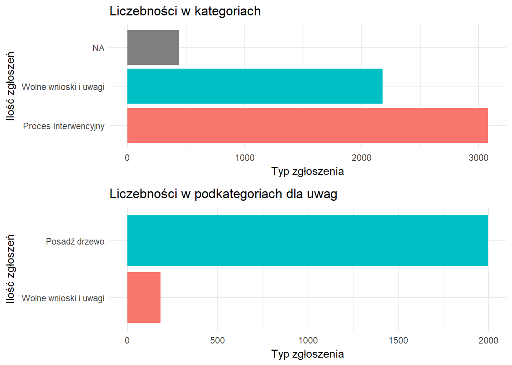

```r
#podkategoria
plot_subkat<-ggplot(df%>%filter(category=='Wolne wnioski i uwagi')%>%.$subcategory%>%table()%>%as.data.frame(),
       aes(x=reorder(., Freq), y=Freq, fill=reorder(., Freq)))+
  geom_bar(stat = 'identity')+coord_flip()+
  #scale_fill_brewer(palette = 'Set3')+
  guides(fill=F)+
  theme_minimal()+
  labs(x='Ilość zgłoszeń', y='Typ zgłoszenia', title='Liczebności w podkategoriach dla uwag')
gridExtra::grid.arrange(plot_kat, plot_subkat)
```

Jak widzimy, jest bardzo dużo zgłoszeń o konieczności posadzenia drzewa w danym miejscu. Jest to dosyć interesujące.

Sprawdźmy teraz jak rozkłada się liczba wniosków we wszystkich podkategoriach:

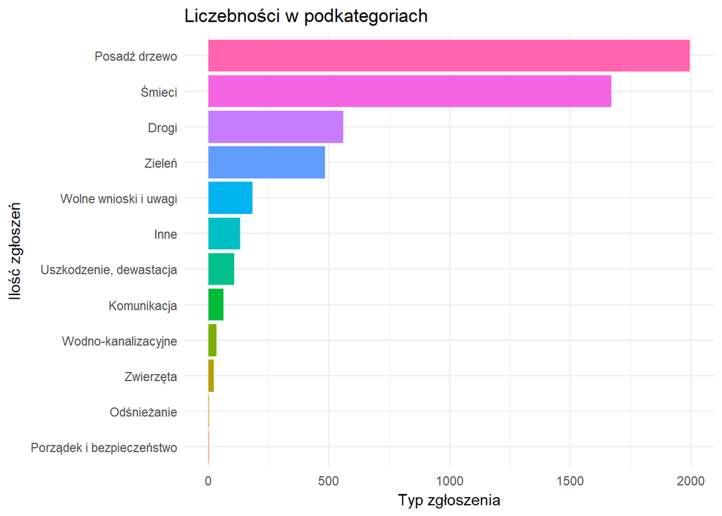

```r
#podkategoria
plot_subkat<-ggplot(df$subcategory%>%table()%>%as.data.frame(),
       aes(x=reorder(., Freq), y=Freq, fill=reorder(., Freq)))+
  geom_bar(stat = 'identity')+coord_flip()+
  guides(fill=F)+
  theme_minimal()+
  labs(x='Ilość zgłoszeń', y='Typ zgłoszenia', title='Liczebności w podkategoriach')

plot_subkat
```

```r
 #data, liczba zgłoszeń i
df$subcategory%>%
  table()%>%
  as.data.frame()%>%
  arrange(desc(Freq))%>%
  head(4)->most_freq
names(most_freq)[1]='nazwa'
most_freq$nazwa%>%as.character()->most_freq


df<-df%>%
  mutate(subcategory_bin=
           ifelse(subcategory %in% most_freq, subcategory, 'inne_bin'))
```

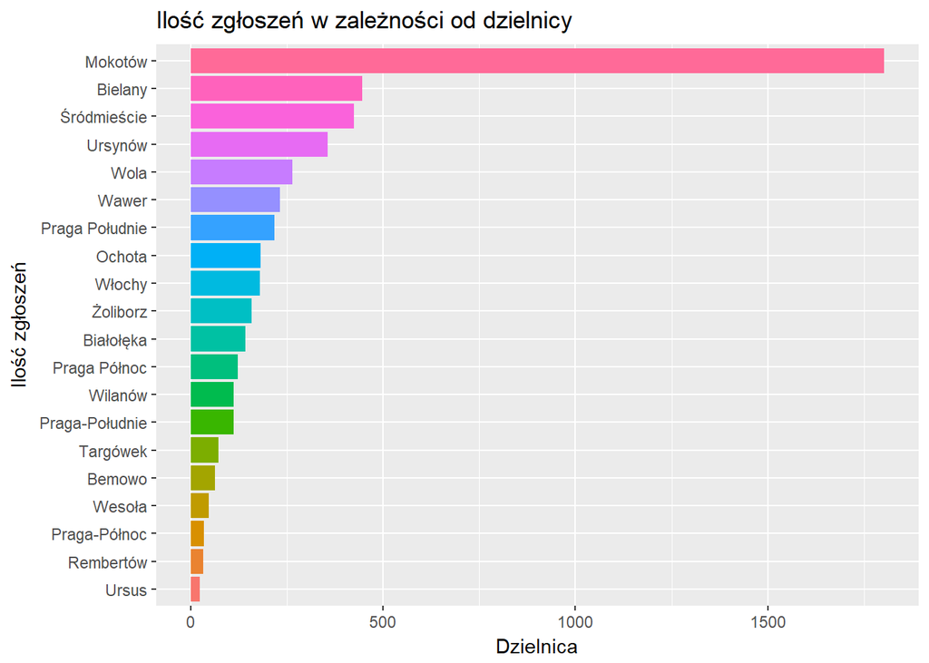

```r
#dzielnica
ggplot(df$district%>%table()%>%as.data.frame(),
       aes(x=reorder(., Freq), y=Freq, fill=reorder(., Freq)))+
  geom_bar(stat = 'identity')+
  coord_flip()+
  labs(x='Ilość zgłoszeń', y='Dzielnica', title='Ilość zgłoszeń w zależności od dzielnicy')+
  guides(fill=FALSE)
```

Sprawdźmy co odpowiada za tak dużą liczbę zgłoszeń na Mokotowie. Podsumowanie według podkategorii:

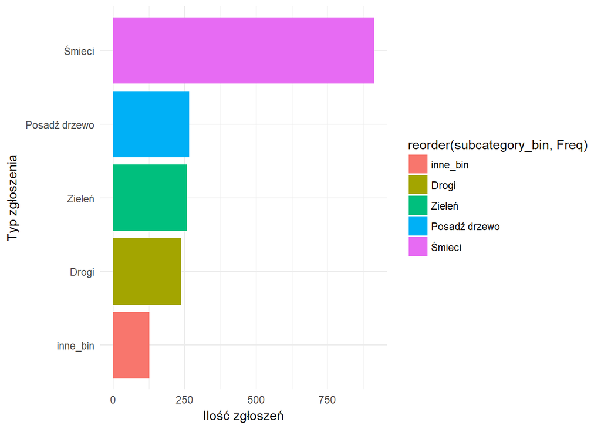

```r
ggplot(df%>%filter(district=='Mokotów')%>%
    group_by(subcategory_bin)%>%
    summarise(Freq=n()),
  aes(x=reorder(subcategory_bin, Freq), y=Freq, fill=reorder(subcategory_bin, Freq)))+
  geom_bar(stat = 'identity')+coord_flip()+
  labs(x='Typ zgłoszenia', y='Ilość zgłoszeń')+
  theme_minimal()
```

Wygląda na to że na Mokotowie mieszkańcy mają problem z wywozem śmieci przez miasto. Sprawdźmy jak wygląda zależność liczby zgłoszeń od czasu (nadal na Mokotowie):

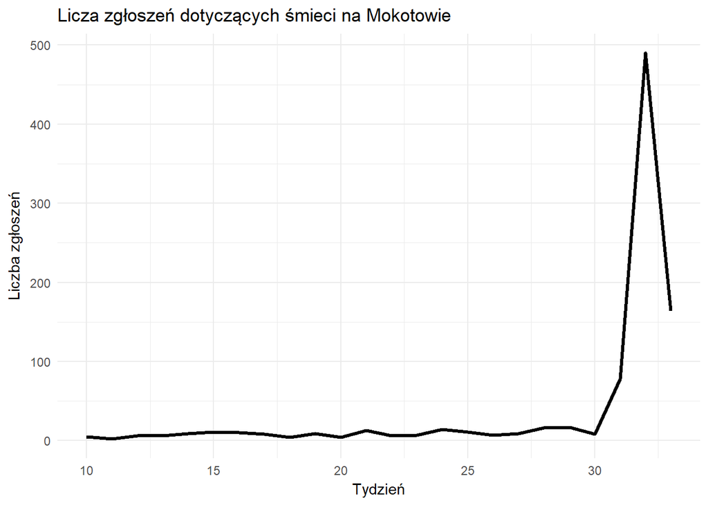

```r
ggplot(df%>%filter(district=='Mokotów' & subcategory=='Śmieci')%>%
         mutate(week=week(createDate))%>%
         group_by(week)%>%summarise(a=n()),
       aes(x=week, y=a))+
  geom_line(size=1.2)+
  labs(x='Tydzień', y='Liczba zgłoszeń', title='Licza zgłoszeń dotyczących śmieci na Mokotowie')+
  theme_minimal()
```

Widzimy bardzo duży wzrost zgłoszeń pod koniec badanego okresu czyli w okolicach sierpnia 2018. Po szybkim wyszukaniu okazało się, że w tym czasie zmieniła się firma odpowiedzialna za wywóz śmieci w tym regionie i były bardzo duże opóźnienia w odbieraniu śmieci. (Cała sprawa opisana jest [tutaj](https://tvnwarszawa.tvn24.pl/informacje,news,mokotow-tonie-w-smieciach-br-nie-sa-wywozone-od-konca-lipca,268132.html))

#### Interwencje

```r
#Event
df$event%>%
  table()%>%
  as.data.frame()%>%
  arrange(desc(Freq))%>%
  head()%>%
  kable()
```

| . | Freq |
| --- | --- |
| Zgłoszenie interwencji w zakresie zieleni przyulicznej, parkowej | 474 |
| Przepełnienie pojemników / worków | 458 |
| Nowy punkt odbioru odpadów | 262 |
| Stan sanitarny pojemników | 208 |
| Uszkodzenie lub brak urządzeń różnych - zamontowanych w jezdniach, chodnikach | 187 |
| Wolne wnioski i uwagi | 183 |

Przejdźmy teraz do analizy ilości wniosków w czasie. Aby usunąć szumy w danych od dnia do dnia, jeden punkt na wykresie odpowiada jednemu tygodniowi.

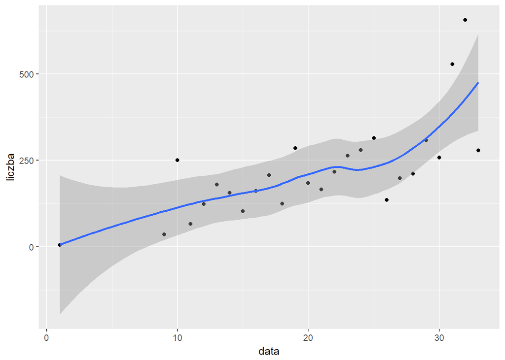

```r
df%>%group_by(week(createDate))%>%
  summarise(liczba=n())->freq_tyg

names(freq_tyg)[1]<-'data'

ggplot(freq_tyg, aes(x=data, y=liczba))+
  geom_point()+
  geom_smooth()
```